# LBB

Inspiration The data-set aims to answer the following key questions:

1. Does various predicting factors which has been chosen initially really affect the Life expectancy? What are the predicting variables actually affecting the life expectancy?
2. Should a country having a lower life expectancy value(<65) increase its healthcare expenditure in order to improve its average lifespan?
3. How does Infant and Adult mortality rates affect life expectancy?
4. Does Life Expectancy has positive or negative correlation with eating habits, lifestyle, exercise, smoking, drinking alcohol etc.
5. What is the impact of schooling on the lifespan of humans?
6. Does Life Expectancy have positive or negative relationship with drinking alcohol?
7. Do densely populated countries tend to have lower life expectancy?
8. What is the impact of Immunization coverage on life Expectancy?

```r
library(dplyr)
library(ggplot2)
library(GGally)
library(tidyr)
library(MLmetrics)
```

```r
options(scipen = 999)
```

```r
life <- read.csv("Life Expectancy Data.csv")
```

```r
str(life)
```

```
'data.frame':   2938 obs. of  22 variables:
 $ Country                        : chr  "Afghanistan" "Afghanistan" "Afghanistan" "Afghanistan" ...
 $ Year                           : int  2015 2014 2013 2012 2011 2010 2009 2008 2007 2006 ...
 $ Status                         : chr  "Developing" "Developing" "Developing" "Developing" ...
 $ Life.expectancy                : num  65 59.9 59.9 59.5 59.2 58.8 58.6 58.1 57.5 57.3 ...
 $ Adult.Mortality                : int  263 271 268 272 275 279 281 287 295 295 ...
 $ infant.deaths                  : int  62 64 66 69 71 74 77 80 82 84 ...
 $ Alcohol                        : num  0.01 0.01 0.01 0.01 0.01 0.01 0.01 0.03 0.02 0.03 ...
 $ percentage.expenditure         : num  71.3 73.5 73.2 78.2 7.1 ...
 $ Hepatitis.B                    : int  65 62 64 67 68 66 63 64 63 64 ...
 $ Measles                        : int  1154 492 430 2787 3013 1989 2861 1599 1141 1990 ...
 $ BMI                            : num  19.1 18.6 18.1 17.6 17.2 16.7 16.2 15.7 15.2 14.7 ...
 $ under.five.deaths              : int  83 86 89 93 97 102 106 110 113 116 ...
 $ Polio                          : int  6 58 62 67 68 66 63 64 63 58 ...
 $ Total.expenditure              : num  8.16 8.18 8.13 8.52 7.87 9.2 9.42 8.33 6.73 7.43 ...
 $ Diphtheria                     : int  65 62 64 67 68 66 63 64 63 58 ...
 $ HIV.AIDS                       : num  0.1 0.1 0.1 0.1 0.1 0.1 0.1 0.1 0.1 0.1 ...
 $ GDP                            : num  584.3 612.7 631.7 670 63.5 ...
 $ Population                     : num  33736494 327582 31731688 3696958 2978599 ...
 $ thinness..1.19.years           : num  17.2 17.5 17.7 17.9 18.2 18.4 18.6 18.8 19 19.2 ...
 $ thinness.5.9.years             : num  17.3 17.5 17.7 18 18.2 18.4 18.7 18.9 19.1 19.3 ...
 $ Income.composition.of.resources: num  0.479 0.476 0.47 0.463 0.454 0.448 0.434 0.433 0.415 0.405 ...
 $ Schooling                      : num  10.1 10 9.9 9.8 9.5 9.2 8.9 8.7 8.4 8.1 ...
```

```r
sapply(life, n_distinct)
```

```
                        Country                            Year
                            193                              16
                         Status                 Life.expectancy
                              2                             363
                Adult.Mortality                   infant.deaths
                            426                             209
                        Alcohol          percentage.expenditure
                           1077                            2328
                    Hepatitis.B                         Measles
                             88                             958
                            BMI               under.five.deaths
                            609                             252
                          Polio               Total.expenditure
                             74                             819
                     Diphtheria                        HIV.AIDS
                             82                             200
                            GDP                      Population
                           2491                            2279
           thinness..1.19.years              thinness.5.9.years
                            201                             208
Income.composition.of.resources                       Schooling
                            626                             174
```

```r
life <- life %>%
  drop_na() %>%
  mutate(Country = as.factor(Country),
         Status = as.factor(Status),
         Year = as.factor(Year))
```

```r
colSums(is.na(life))
```

```
                        Country                            Year
                              0                               0
                         Status                 Life.expectancy
                              0                               0
                Adult.Mortality                   infant.deaths
                              0                               0
                        Alcohol          percentage.expenditure
                              0                               0
                    Hepatitis.B                         Measles
                              0                               0
                            BMI               under.five.deaths
                              0                               0
                          Polio               Total.expenditure
                              0                               0
                     Diphtheria                        HIV.AIDS
                              0                               0
                            GDP                      Population
                              0                               0
           thinness..1.19.years              thinness.5.9.years
                              0                               0
Income.composition.of.resources                       Schooling
                              0                               0
```

```r
life
```

| Country | Year | Status | Life.expectancy | Adult.Mortality | infant.deaths | Alcohol | percentage.expenditure | Hepatitis.B | Measles | BMI | under.five.deaths | Polio | Total.expenditure | Diphtheria | HIV.AIDS | GDP | Population | thinness..1.19.years | thinness.5.9.years | Income.composition.of.resources | Schooling |
| --- | --- | --- | --- | --- | --- | --- | --- | --- | --- | --- | --- | --- | --- | --- | --- | --- | --- | --- | --- | --- | --- |
| Afghanistan | 2015 | Developing | 65.0 | 263 | 62 | 0.01 | 71.2796236 | 65 | 1154 | 19.1 | 83 | 6 | 8.16 | 65 | 0.1 | 584.259210 | 33736494 | 17.2 | 17.3 | 0.479 | 10.1 |
| Afghanistan | 2014 | Developing | 59.9 | 271 | 64 | 0.01 | 73.5235817 | 62 | 492 | 18.6 | 86 | 58 | 8.18 | 62 | 0.1 | 612.696514 | 327582 | 17.5 | 17.5 | 0.476 | 10.0 |
| Afghanistan | 2013 | Developing | 59.9 | 268 | 66 | 0.01 | 73.2192427 | 64 | 430 | 18.1 | 89 | 62 | 8.13 | 64 | 0.1 | 631.744976 | 31731688 | 17.7 | 17.7 | 0.470 | 9.9 |
| Afghanistan | 2012 | Developing | 59.5 | 272 | 69 | 0.01 | 78.1842153 | 67 | 2787 | 17.6 | 93 | 67 | 8.52 | 67 | 0.1 | 669.959000 | 3696958 | 17.9 | 18.0 | 0.463 | 9.8 |
| Afghanistan | 2011 | Developing | 59.2 | 275 | 71 | 0.01 | 7.0971087 | 68 | 3013 | 17.2 | 97 | 68 | 7.87 | 68 | 0.1 | 63.537231 | 2978599 | 18.2 | 18.2 | 0.454 | 9.5 |
| Afghanistan | 2010 | Developing | 58.8 | 279 | 74 | 0.01 | 79.6793674 | 66 | 1989 | 16.7 | 102 | 66 | 9.20 | 66 | 0.1 | 553.328940 | 2883167 | 18.4 | 18.4 | 0.448 | 9.2 |
| Afghanistan | 2009 | Developing | 58.6 | 281 | 77 | 0.01 | 56.7622168 | 63 | 2861 | 16.2 | 106 | 63 | 9.42 | 63 | 0.1 | 445.893298 | 284331 | 18.6 | 18.7 | 0.434 | 8.9 |
| Afghanistan | 2008 | Developing | 58.1 | 287 | 80 | 0.03 | 25.8739254 | 64 | 1599 | 15.7 | 110 | 64 | 8.33 | 64 | 0.1 | 373.361116 | 2729431 | 18.8 | 18.9 | 0.433 | 8.7 |
| Afghanistan | 2007 | Developing | 57.5 | 295 | 82 | 0.02 | 10.9101560 | 63 | 1141 | 15.2 | 113 | 63 | 6.73 | 63 | 0.1 | 369.835796 | 26616792 | 19.0 | 19.1 | 0.415 | 8.4 |
| Afghanistan | 2006 | Developing | 57.3 | 295 | 84 | 0.03 | 17.1715175 | 64 | 1990 | 14.7 | 116 | 58 | 7.43 | 58 | 0.1 | 272.563770 | 2589345 | 19.2 | 19.3 | 0.405 | 8.1 |

[output cut: 990 more lines]

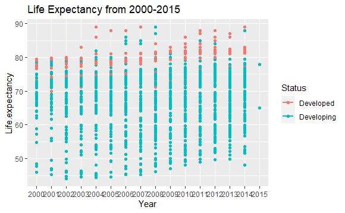

```r
ggplot(data=life,mapping=aes(Year,Life.expectancy,color=Status))+
  geom_point()+
  geom_smooth(method="lm",se=FALSE)+
  labs(title="Life Expectancy from 2000-2015")
```

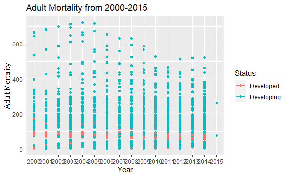

```r
ggplot(data=life,mapping=aes(Year,Adult.Mortality,color=Status))+
  geom_point()+
  geom_smooth(method="lm",se=FALSE)+
  labs(title="Adult Mortality from 2000-2015")
```

```r
life_exp <- life %>%
  select(-c("Country","Year","Status"))
```

```r
model_all <- lm(formula = Life.expectancy~., data = life_exp)
summary(model_all)
```

```
Call:
lm(formula = Life.expectancy ~ ., data = life_exp)

Residuals:
     Min       1Q   Median       3Q      Max
-17.0176  -2.0454  -0.0185   2.2260  11.9157

Coefficients:
                                        Estimate       Std. Error
(Intercept)                     53.2815590198721  0.7358126406486
Adult.Mortality                 -0.0168885301997  0.0009472912705
infant.deaths                    0.0936938378330  0.0106765961044
Alcohol                         -0.0543483450424  0.0306070454392
percentage.expenditure           0.0003776826235  0.0001804691153
Hepatitis.B                     -0.0055824997053  0.0044461852137
Measles                         -0.0000086173382  0.0000108065835
BMI                              0.0334980599049  0.0060106760259
under.five.deaths               -0.0704701961145  0.0077282061768
Polio                            0.0078363788927  0.0051632463325
Total.expenditure                0.0797522210770  0.0407415696170
Diphtheria                       0.0143889186959  0.0059383017027
HIV.AIDS                        -0.4382980476500  0.0178758984580
GDP                              0.0000138327405  0.0000283772875
Population                      -0.0000000006917  0.0000000017525
thinness..1.19.years            -0.0086702286839  0.0531024439158
thinness.5.9.years              -0.0512278223876  0.0524179265759
Income.composition.of.resources  9.8241467234536  0.8339594781239
Schooling                        0.8783349550519  0.0593903821788
                                t value             Pr(>|t|)
(Intercept)                      72.412 < 0.0000000000000002 ***
Adult.Mortality                 -17.828 < 0.0000000000000002 ***
infant.deaths                     8.776 < 0.0000000000000002 ***
Alcohol                          -1.776               0.0760 .
percentage.expenditure            2.093               0.0365 *
Hepatitis.B                      -1.256               0.2095
Measles                          -0.797               0.4253
BMI                               5.573         0.0000000292 ***
under.five.deaths                -9.119 < 0.0000000000000002 ***
Polio                             1.518               0.1293
Total.expenditure                 1.958               0.0505 .
Diphtheria                        2.423               0.0155 *
HIV.AIDS                        -24.519 < 0.0000000000000002 ***
GDP                               0.487               0.6260
Population                       -0.395               0.6931
thinness..1.19.years             -0.163               0.8703
thinness.5.9.years               -0.977               0.3286
Income.composition.of.resources  11.780 < 0.0000000000000002 ***
Schooling                        14.789 < 0.0000000000000002 ***
---
Signif. codes:  0 ‘***’ 0.001 ‘**’ 0.01 ‘*’ 0.05 ‘.’ 0.1 ‘ ’ 1

Residual standard error: 3.596 on 1630 degrees of freedom
Multiple R-squared:  0.8347,    Adjusted R-squared:  0.8329
F-statistic: 457.4 on 18 and 1630 DF,  p-value: < 0.00000000000000022
```

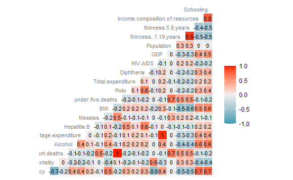

```r
ggcorr(life_exp, label = TRUE, label_size = 3, hjust = 1, size = 3, color = "grey50")
```

> > Kesimpulan : Schooling , Income Composition of Resources, Adult.Mortality, HIV.AIDS, BMI

```r
model_cor <-  lm(formula = Life.expectancy~Schooling + Income.composition.of.resources + HIV.AIDS + BMI + Adult.Mortality , data = life_exp)
summary(model_cor)
```

```
Call:
lm(formula = Life.expectancy ~ Schooling + Income.composition.of.resources +
    HIV.AIDS + BMI + Adult.Mortality, data = life_exp)

Residuals:
     Min       1Q   Median       3Q      Max
-17.8214  -2.0668   0.0201   2.2090  11.6230

Coefficients:
                                  Estimate Std. Error t value
(Intercept)                     52.6184529  0.5371613   97.96
Schooling                        1.0085997  0.0566966   17.79
Income.composition.of.resources 11.0886261  0.8471361   13.09
HIV.AIDS                        -0.4376488  0.0186014  -23.53
BMI                              0.0394104  0.0058044    6.79
Adult.Mortality                 -0.0188908  0.0009793  -19.29
                                            Pr(>|t|)
(Intercept)                     < 0.0000000000000002 ***
Schooling                       < 0.0000000000000002 ***
Income.composition.of.resources < 0.0000000000000002 ***
HIV.AIDS                        < 0.0000000000000002 ***
BMI                                  0.0000000000156 ***
Adult.Mortality                 < 0.0000000000000002 ***
---
Signif. codes:  0 ‘***’ 0.001 ‘**’ 0.01 ‘*’ 0.05 ‘.’ 0.1 ‘ ’ 1

Residual standard error: 3.796 on 1643 degrees of freedom
Multiple R-squared:  0.8144,    Adjusted R-squared:  0.8138
F-statistic:  1442 on 5 and 1643 DF,  p-value: < 0.00000000000000022
```

```r
model_dis <- lm(formula = Life.expectancy~ Alcohol + Hepatitis.B + Measles +
    Polio + Diphtheria + HIV.AIDS , data = life_exp)
summary(model_dis)
```

```
Call:
lm(formula = Life.expectancy ~ Alcohol + Hepatitis.B + Measles +
    Polio + Diphtheria + HIV.AIDS, data = life_exp)

Residuals:
    Min      1Q  Median      3Q     Max
-22.034  -3.982   0.516   4.013  15.152

Coefficients:
               Estimate  Std. Error t value             Pr(>|t|)
(Intercept) 59.99023508  0.66747258  89.877 < 0.0000000000000002 ***
Alcohol      0.71361075  0.03786951  18.844 < 0.0000000000000002 ***
Hepatitis.B -0.01064931  0.00723883  -1.471              0.14145
Measles     -0.00003785  0.00001466  -2.582              0.00991 **
Polio        0.04439779  0.00841936   5.273        0.00000015179 ***
Diphtheria   0.05831467  0.00962655   6.058        0.00000000171 ***
HIV.AIDS    -0.81286928  0.02449543 -33.185 < 0.0000000000000002 ***
---
Signif. codes:  0 ‘***’ 0.001 ‘**’ 0.01 ‘*’ 0.05 ‘.’ 0.1 ‘ ’ 1

Residual standard error: 5.948 on 1642 degrees of freedom
Multiple R-squared:  0.5445,    Adjusted R-squared:  0.5428
F-statistic: 327.1 on 6 and 1642 DF,  p-value: < 0.00000000000000022
```

```r
summary(model_all)$adj.r.squared
```

```
[1] 0.8329127
```

```r
summary(model_cor)$adj.r.squared
```

```
[1] 0.8138188
```

```r
summary(model_dis)$adj.r.squared
```

```
[1] 0.5427931
```

> Kesimpulan: Pada kasus ini, model dengan seluruh kolom sebagai prediktor adalah model terbaik

```r
pred <- model_all$fitted.values
life_exp$prediksi <- pred
head(life_exp)
```

|  | Life.expectancy | Adult.Mortality | infant.deaths | Alcohol | percentage.expenditure | Hepatitis.B | Measles | BMI | under.five.deaths | Polio | Total.expenditure | Diphtheria | HIV.AIDS | GDP | Population | thinness..1.19.years | thinness.5.9.years | Income.composition.of.resources | Schooling | prediksi |
| --- | --- | --- | --- | --- | --- | --- | --- | --- | --- | --- | --- | --- | --- | --- | --- | --- | --- | --- | --- | --- |
| 1 | 65.0 | 263 | 62 | 0.01 | 71.279624 | 65 | 1154 | 19.1 | 83 | 6 | 8.16 | 65 | 0.1 | 584.25921 | 33736494 | 17.2 | 17.3 | 0.479 | 10.1 | 63.20883 |
| 2 | 59.9 | 271 | 64 | 0.01 | 73.523582 | 62 | 492 | 18.6 | 86 | 58 | 8.18 | 62 | 0.1 | 612.69651 | 327582 | 17.5 | 17.5 | 0.476 | 10.0 | 63.31551 |
| 3 | 59.9 | 268 | 66 | 0.01 | 73.219243 | 64 | 430 | 18.1 | 89 | 62 | 8.13 | 64 | 0.1 | 631.74498 | 31731688 | 17.7 | 17.7 | 0.470 | 9.9 | 63.19058 |
| 4 | 59.5 | 272 | 69 | 0.01 | 78.184215 | 67 | 2787 | 17.6 | 93 | 67 | 8.52 | 67 | 0.1 | 669.95900 | 3696958 | 17.9 | 18.0 | 0.463 | 9.8 | 63.02996 |
| 5 | 59.2 | 275 | 71 | 0.01 | 7.097109 | 68 | 3013 | 17.2 | 97 | 68 | 7.87 | 68 | 0.1 | 63.53723 | 2978599 | 18.2 | 18.2 | 0.454 | 9.5 | 62.43476 |
| 6 | 58.8 | 279 | 74 | 0.01 | 79.679367 | 66 | 1989 | 16.7 | 102 | 66 | 9.20 | 66 | 0.1 | 553.32894 | 2883167 | 18.4 | 18.4 | 0.448 | 9.2 | 62.06062 |

[output not shown]

[output cut: 990 more lines]

```r
RMSE(model_all$fitted.values, life_exp$Life.expectancy)
```

```
[1] 3.575046
```

```r
MAPE(life_exp$prediksi, life_exp$Life.expectancy) * 100
```

```
[1] 4.111535
```

```r
# model tanpa prediktor
model_life_non <- lm(formula = Life.expectancy ~ 1, data = life_exp)
# model dengan semua prediktor
model_life_all <- lm(formula = Life.expectancy ~ ., data = life_exp)
```

```r
both_model <- step(model_life_non, direction = "both",
     scope = list(lower = model_life_non, upper = model_life_all), trace = 0)

summary(both_model)
```

```
Call:
lm(formula = Life.expectancy ~ prediksi, data = life_exp)

Residuals:
     Min       1Q   Median       3Q      Max
-17.0176  -2.0454  -0.0185   2.2260  11.9157

Coefficients:
                       Estimate          Std. Error t value
(Intercept) -0.0000000000000224  0.7649130750020414    0.00
prediksi     0.9999999999999994  0.0109639006364456   91.21
                       Pr(>|t|)
(Intercept)                   1
prediksi    <0.0000000000000002 ***
---
Signif. codes:  0 ‘***’ 0.001 ‘**’ 0.01 ‘*’ 0.05 ‘.’ 0.1 ‘ ’ 1

Residual standard error: 3.577 on 1647 degrees of freedom
Multiple R-squared:  0.8347,    Adjusted R-squared:  0.8346
F-statistic:  8319 on 1 and 1647 DF,  p-value: < 0.00000000000000022
```

```r
# Backward elimination
backward_model <- step(model_life_all, trace = 0)
summary(backward_model)
```

```
Call:
lm(formula = Life.expectancy ~ Adult.Mortality + infant.deaths +
    Alcohol + percentage.expenditure + BMI + under.five.deaths +
    Total.expenditure + Diphtheria + HIV.AIDS + thinness.5.9.years +
    Income.composition.of.resources + Schooling, data = life_exp)

Residuals:
     Min       1Q   Median       3Q      Max
-17.0473  -2.0562  -0.0251   2.2284  11.8901

Coefficients:
                                   Estimate  Std. Error t value
(Intercept)                     53.29869642  0.70705142  75.382
Adult.Mortality                 -0.01697277  0.00094442 -17.972
infant.deaths                    0.09172725  0.00997436   9.196
Alcohol                         -0.05149409  0.03044215  -1.692
percentage.expenditure           0.00046511  0.00005764   8.069
BMI                              0.03347906  0.00596098   5.616
under.five.deaths               -0.06945120  0.00740961  -9.373
Total.expenditure                0.07897814  0.04060958   1.945
Diphtheria                       0.01497124  0.00453173   3.304
HIV.AIDS                        -0.43741215  0.01783626 -24.524
thinness.5.9.years              -0.05658930  0.02644506  -2.140
Income.composition.of.resources  9.88312385  0.83050888  11.900
Schooling                        0.88690121  0.05863986  15.125
                                            Pr(>|t|)
(Intercept)                     < 0.0000000000000002 ***
Adult.Mortality                 < 0.0000000000000002 ***
infant.deaths                   < 0.0000000000000002 ***
Alcohol                                     0.090924 .
percentage.expenditure           0.00000000000000136 ***
BMI                              0.00000002287469714 ***
under.five.deaths               < 0.0000000000000002 ***
Total.expenditure                           0.051968 .
Diphtheria                                  0.000975 ***
HIV.AIDS                        < 0.0000000000000002 ***
thinness.5.9.years                          0.032512 *
Income.composition.of.resources < 0.0000000000000002 ***
Schooling                       < 0.0000000000000002 ***
---
Signif. codes:  0 ‘***’ 0.001 ‘**’ 0.01 ‘*’ 0.05 ‘.’ 0.1 ‘ ’ 1

Residual standard error: 3.594 on 1636 degrees of freedom
Multiple R-squared:  0.8343,    Adjusted R-squared:  0.8331
F-statistic: 686.4 on 12 and 1636 DF,  p-value: < 0.00000000000000022
```

```r
forward_model <- step(model_life_non, direction = "forward",
     scope = list(lower = model_life_non, upper = model_life_all), trace = 0)
summary(forward_model)
```

```
Call:
lm(formula = Life.expectancy ~ prediksi, data = life_exp)

Residuals:
     Min       1Q   Median       3Q      Max
-17.0176  -2.0454  -0.0185   2.2260  11.9157

Coefficients:
                       Estimate          Std. Error t value
(Intercept) -0.0000000000000224  0.7649130750020414    0.00
prediksi     0.9999999999999994  0.0109639006364456   91.21
                       Pr(>|t|)
(Intercept)                   1
prediksi    <0.0000000000000002 ***
---
Signif. codes:  0 ‘***’ 0.001 ‘**’ 0.01 ‘*’ 0.05 ‘.’ 0.1 ‘ ’ 1

Residual standard error: 3.577 on 1647 degrees of freedom
Multiple R-squared:  0.8347,    Adjusted R-squared:  0.8346
F-statistic:  8319 on 1 and 1647 DF,  p-value: < 0.00000000000000022
```

```r
library(performance)
compare_performance(backward_model, forward_model, both_model)
```

```
# Comparison of Model Performance Indices

Name           | Model |      AIC | AIC weights |      BIC | BIC weights |    R2 | R2 (adj.) |  RMSE | Sigma
------------------------------------------------------------------------------------------------------------
backward_model |    lm | 8913.582 |     < 0.001 | 8989.293 |     < 0.001 | 0.834 |     0.833 | 3.580 | 3.594
forward_model  |    lm | 8887.238 |       0.500 | 8903.462 |       0.500 | 0.835 |     0.835 | 3.575 | 3.577
both_model     |    lm | 8887.238 |       0.500 | 8903.462 |       0.500 | 0.835 |     0.835 | 3.575 | 3.577
```

> both model and forward model sama sama baik

```r
life_2 <- life_exp
```

```r
pred <- both_model$fitted.values
life_2$prediksi <- pred
head(life_2)
```

|  | Life.expectancy | Adult.Mortality | infant.deaths | Alcohol | percentage.expenditure | Hepatitis.B | Measles | BMI | under.five.deaths | Polio | Total.expenditure | Diphtheria | HIV.AIDS | GDP | Population | thinness..1.19.years | thinness.5.9.years | Income.composition.of.resources | Schooling | prediksi |
| --- | --- | --- | --- | --- | --- | --- | --- | --- | --- | --- | --- | --- | --- | --- | --- | --- | --- | --- | --- | --- |
| 1 | 65.0 | 263 | 62 | 0.01 | 71.279624 | 65 | 1154 | 19.1 | 83 | 6 | 8.16 | 65 | 0.1 | 584.25921 | 33736494 | 17.2 | 17.3 | 0.479 | 10.1 | 63.20883 |
| 2 | 59.9 | 271 | 64 | 0.01 | 73.523582 | 62 | 492 | 18.6 | 86 | 58 | 8.18 | 62 | 0.1 | 612.69651 | 327582 | 17.5 | 17.5 | 0.476 | 10.0 | 63.31551 |
| 3 | 59.9 | 268 | 66 | 0.01 | 73.219243 | 64 | 430 | 18.1 | 89 | 62 | 8.13 | 64 | 0.1 | 631.74498 | 31731688 | 17.7 | 17.7 | 0.470 | 9.9 | 63.19058 |
| 4 | 59.5 | 272 | 69 | 0.01 | 78.184215 | 67 | 2787 | 17.6 | 93 | 67 | 8.52 | 67 | 0.1 | 669.95900 | 3696958 | 17.9 | 18.0 | 0.463 | 9.8 | 63.02996 |
| 5 | 59.2 | 275 | 71 | 0.01 | 7.097109 | 68 | 3013 | 17.2 | 97 | 68 | 7.87 | 68 | 0.1 | 63.53723 | 2978599 | 18.2 | 18.2 | 0.454 | 9.5 | 62.43476 |
| 6 | 58.8 | 279 | 74 | 0.01 | 79.679367 | 66 | 1989 | 16.7 | 102 | 66 | 9.20 | 66 | 0.1 | 553.32894 | 2883167 | 18.4 | 18.4 | 0.448 | 9.2 | 62.06062 |

```r
RMSE(both_model$fitted.values, life_2$Life.expectancy)
```

```
[1] 3.575046
```

```r
MAPE(life_2$prediksi, life_2$Life.expectancy) * 100
```

```
[1] 4.111535
```

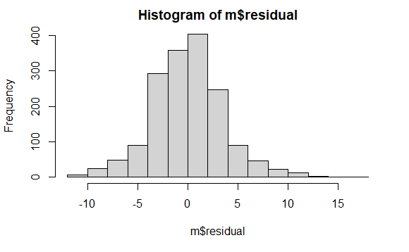

```r
hist(m$residual, breaks=20)
```

```r
shapiro.test(m$residual)
```

```
    Shapiro-Wilk normality test

data:  m$residual
W = 0.98981, p-value = 0.000000002464
```